# Notes on Intra-day Apple Health Export

Outside Online article on watch: https://www.outsideonline.com/2006026/apples-fitness-guru-opens-about-watch#close (with ABC video of Apple lab)

Apple Watch 6 health and fitness press release https://www.apple.com/newsroom/2019/06/watchos-6-advances-health-and-fitness-capabilities-for-apple-watch/

forensic detail about health kit: https://blog.elcomsoft.com/2019/01/securing-and-extracting-health-data-apple-health-vs-google-fit/

See [Harris-Bennett formula for basal energy](https://en.wikipedia.org/wiki/Harris–Benedict_equation)

The Harris–Benedict equations revised by [Mifflin and St Jeor in 1990](https://pubmed.ncbi.nlm.nih.gov/2305711-a-new-predictive-equation-for-resting-energy-expenditure-in-healthy-individuals/):[4]

Men BMR = (10 × weight in kg) + (6.25 × height in cm) - (5 × age in years) + 5 Women BMR = (10 × weight in kg) + (6.25 × height in cm) - (5 × age in years) - 161

```r
bmr <- (10 * 146 * 0.4536) + ( 6.25 * 69 * 2.54) - (5 * 69) + 5
print(bmr)
```

```
[1] 1417.631
```

```r
print(bmr * 1.76)
```

```
[1] 2495.031
```

```r
bmr / (24 * 60 * 60) # calories per second
```

```
[1] 0.01640777
```

basal energy per day by version

| sourceVersion | start | end | days | total_basal | mean_basal |
| --- | --- | --- | --- | --- | --- |
| 4.0 | 2017-10-03 14:30:26 | 2017-11-30 09:24:11 | 59 | 93740.99 | 1588.830 |
| 4.1 | 2017-11-30 09:39:01 | 2017-12-14 22:31:21 | 16 | 23445.08 | 1465.317 |
| 4.2 | 2017-12-14 22:45:51 | 2018-09-22 16:33:08 | 201 | 322255.41 | 1603.261 |
| 4.2.2 | 2018-01-23 19:50:16 | 2018-03-12 17:49:58 | 48 | 78766.13 | 1640.961 |
| 4.2.3 | 2018-03-12 18:05:50 | 2018-04-13 15:21:19 | 33 | 52313.42 | 1585.255 |
| 5.0 | 2018-09-22 16:38:35 | 2018-10-09 19:15:56 | 18 | 27442.86 | 1524.603 |
| 5.0.1 | 2018-09-30 13:34:32 | 2018-11-18 21:51:07 | 51 | 82885.97 | 1625.215 |
| 5.1.1 | 2018-11-18 22:06:21 | 2018-12-08 08:07:16 | 20 | 33513.85 | 1675.692 |
| 5.1.2 | 2018-12-08 08:14:46 | 2019-01-22 20:04:05 | 47 | 78449.39 | 1669.136 |
| 5.1.3 | 2019-01-22 20:18:36 | 2019-04-16 20:29:09 | 85 | 144305.82 | 1697.716 |

[output cut: 9 more lines]

Some notes on events: walk on 2/19/2020 15:02 to 16:04, no workout 2/23/2020 14:15 to 15:20 no workout 2/21/2020 no workout 13:15 to 14:20 no workout 2/28/2020 13:31 to 14:38

2/25/2020 removed watch 14:12 to 15:50 # example of long off period: utc 2019-09-18 21:18:55 2/27/2020 removed watch 08:56 to 09:16

battery ran out of power on 2/28/2020

version 5.0 start 2018-09-22 16:38:35 version 5.01 2018-09-30 13:34:32 version 5.1.1 2018-11-18 22:06:21

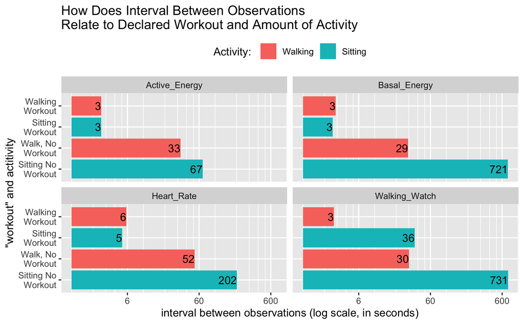

[Apple Developer Guidelines](https://developer.apple.com/design/human-interface-guidelines/watchos/user-interaction/accelerometer-and-gyroscope/) Use motion data to offer a tangible benefit to the user. The gathering of motion data should offer a tangible benefit to the user. For example, fitness apps use the data to provide feedback about the user’s activity and general health. Do not record data simply to have the data.

guy became suspect because of fitness tracking https://www.nbcnews.com/news/us-news/google-tracked-his-bike-ride-past-burglarized-home-made-him-n1151761

```r
y2020 <- intra4 %>%
  filter(year(utc_start) == 2020, !is.na(workout_utc_start)) %>%
  group_by(workout_utc_start, workout_utc_end) %>%
  summarise(basal_sum = sum(value * (type == "BasalEnergyBurned"), na.rm = TRUE),
            active_sum = sum(value * (type == "ActiveEnergyBurned"), na.rm = TRUE),
            duration = last(duration)) %>%
  left_join(workout_df %>% select(utc_start, utc_end, duration, totalEnergyBurned),
            by = c("workout_utc_start" = "utc_start", "workout_utc_end" = "utc_end"))
```

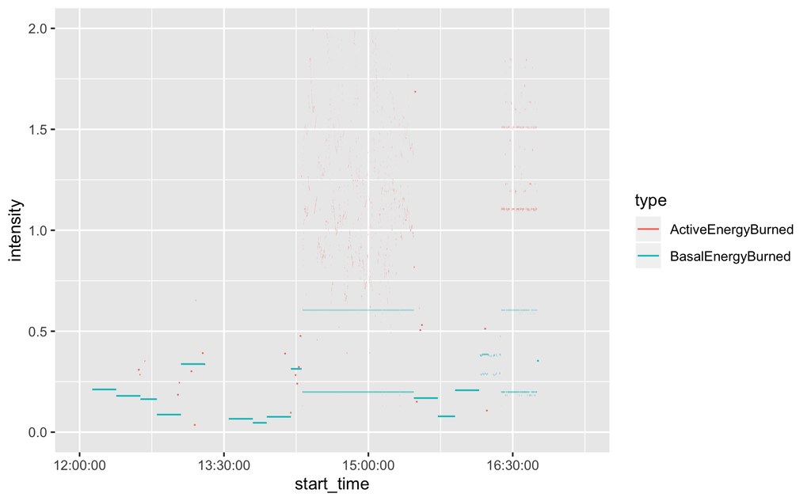

More detail on intra-day

```r
asample <- show_area(intra4, ymd_hms("2020-02-10 13:55:41"), n = 1000)
```